# Soil Sample project

##### Figure 1. This shows a stacked bar chart to visualise the composition of microbial communities within different samples at a specific taxonomic level, in this case, the phylum. In this stacked bar chart. The x-axis represents different samples labelled barcode01, barcode02, etc. The y-axis shows the abundance, which is usually the number of sequences or reads assigned to each taxonomic group within the sample, indicating the presence and quantity of the microbes. Each coloured segment of the bar represents a different phylum. The height of the segment is proportional to the abundance of that phylum in the sample. The legend on the right matches the colour coding in the bars to the phylum names, allowing you to identify which colours correspond to which microbial groups.

sample_sums(microbiome)

```r
rarefiedData <- rarefy_even_depth(microbiome,
    sample.size = min(sample_sums(microbiome)), replace = F)
```

```
## You set `rngseed` to FALSE. Make sure you've set & recorded
##  the random seed of your session for reproducibility.
## See `?set.seed`
```

```
## ...
```

```
## 149OTUs were removed because they are no longer
## present in any sample after random subsampling
```

```
## ...
```

```r
sample_sums(rarefiedData)
```

```
## barcode01 barcode03 barcode04 barcode02
##    395805    395805    395805    395805
```

```r
estimate_richness(rarefiedData)
```

```
##           Observed    Chao1 se.chao1      ACE   se.ACE  Shannon   Simpson
## barcode01     2166 2614.581 59.13886 2511.174 24.84506 5.200157 0.9799104
## barcode03     2237 2611.961 48.48299 2602.706 25.46582 5.754698 0.9934920
## barcode04     2002 2453.045 56.49796 2437.722 24.93885 4.885938 0.9743510
## barcode02     2705 3196.012 58.44116 3100.111 27.67502 5.260288 0.9818352
##           InvSimpson   Fisher
## barcode01   49.77692 301.6664
## barcode03  153.65624 313.1885
## barcode04   38.98783 275.3244
## barcode02   55.05141 390.8153
```

```r
rarefiedData <- rarefy_even_depth(microbiome,
    sample.size = min(sample_sums(microbiome)), replace = F)
```

```
## You set `rngseed` to FALSE. Make sure you've set & recorded
##  the random seed of your session for reproducibility.
## See `?set.seed`
##
## ...
```

```
## 144OTUs were removed because they are no longer
## present in any sample after random subsampling
```

```
## ...
```

```r
sample_sums(rarefiedData)
```

```
## barcode01 barcode03 barcode04 barcode02
##    395805    395805    395805    395805
```

```r
estimate_richness(rarefiedData) # summarises the diversity of each sample
```

```
##           Observed    Chao1 se.chao1      ACE   se.ACE  Shannon   Simpson
## barcode01     2167 2621.963 59.71236 2519.326 24.94629 5.201014 0.9799564
## barcode03     2262 2641.442 48.64068 2632.544 25.63376 5.756424 0.9935038
## barcode04     1993 2559.885 71.68318 2442.061 24.97884 4.883916 0.9743093
## barcode02     2705 3196.012 58.44116 3100.111 27.67502 5.260288 0.9818352
##           InvSimpson   Fisher
## barcode01   49.89129 301.8282
## barcode03  153.93680 317.2622
## barcode04   38.92459 273.8901
## barcode02   55.05141 390.8153
```

```r
richness_data <- estimate_richness(rarefiedData, measures = c("ACE", "Shannon"))

# View the first few lines of the diversity data
head(richness_data)
```

```
##                ACE   se.ACE  Shannon
## barcode01 2519.326 24.94629 5.201014
## barcode03 2632.544 25.63376 5.756424
## barcode04 2442.061 24.97884 4.883916
## barcode02 3100.111 27.67502 5.260288
```

```r
barcode_metrics <- data.frame(
  Barcode = c("barcode01", "barcode03"),
  ACE = c(1214.884, 1304.168),
  Shannon = c(5.139960, 5.683512)
)

# Descriptive comparison
difference_ace <- barcode_metrics$ACE[barcode_metrics$Barcode == "barcode03"] -
                  barcode_metrics$ACE[barcode_metrics$Barcode == "barcode01"]

difference_shannon <- barcode_metrics$Shannon[barcode_metrics$Barcode == "barcode03"] -
                      barcode_metrics$Shannon[barcode_metrics$Barcode == "barcode01"]

# Print the observed differences
print(paste("Difference in ACE between barcode03 and barcode01:", difference_ace))
```

```
## [1] "Difference in ACE between barcode03 and barcode01: 89.2839999999999"
```

```r
print(paste("Difference in Shannon index between barcode03 and barcode01:", difference_shannon))
```

```
## [1] "Difference in Shannon index between barcode03 and barcode01: 0.543552"
```

```r
# Biodiversity metrics
barcode_metrics <- data.frame(
  Barcode = c("barcode04", "barcode05"),
  ACE = c(1460.731, 1071.254), # ACE values for barcode02 and barcode05
  Shannon = c(5.199304, 5.250453) # Shannon values for barcode02 and barcode05
)
# Descriptive comparison
difference_ace <- barcode_metrics$ACE[barcode_metrics$Barcode == "barcode05"] -
                  barcode_metrics$ACE[barcode_metrics$Barcode == "barcode02"]

difference_shannon <- barcode_metrics$Shannon[barcode_metrics$Barcode == "barcode05"] -
                      barcode_metrics$Shannon[barcode_metrics$Barcode == "barcode02"]

# Print the observed differences
print(paste("Difference in ACE between barcode05 and barcode02:", difference_ace))
```

```
## [1] "Difference in ACE between barcode05 and barcode02: "
```

```r
print(paste("Difference in Shannon index between barcode05 and barcode02:", difference_shannon))
```

```
## [1] "Difference in Shannon index between barcode05 and barcode02: "
```

```r
grouped_richness <- richness_data %>%
  mutate(Group = case_when(
    grepl("barcode01|barcode04", rownames(.)) ~ "Garden",
    grepl("barcode02|barcode03", rownames(.)) ~ "University",
    TRUE ~ as.character(rownames(.))  # This line is optional, keeps other row names as they are
  ))
# To view the first few rows of the grouped data
head(grouped_richness)
```

```
##                ACE   se.ACE  Shannon      Group
## barcode01 2519.326 24.94629 5.201014     Garden
## barcode03 2632.544 25.63376 5.756424 University
## barcode04 2442.061 24.97884 4.883916     Garden
## barcode02 3100.111 27.67502 5.260288 University
```

```r
garden_values <- filter(grouped_richness, Group == "Garden")$ACE
university_values <- filter(grouped_richness, Group == "University")$ACE

# Performing the t-test
t_test_result <- t.test(garden_values, university_values)

# Viewing the results
print(t_test_result)
```

```
##
##  Welch Two Sample t-test
##
## data:  garden_values and university_values
## t = -1.6275, df = 1.0546, p-value = 0.3413
## alternative hypothesis: true difference in means is not equal to 0
## 95 percent confidence interval:
##  -3052.080  2280.813
## sample estimates:
## mean of x mean of y
##  2480.694  2866.327
```

```r
# Extracting ACE values for each group
garden_values <- filter(grouped_richness, Group == "Garden")$Shannon
university_values <- filter(grouped_richness, Group == "University")$Shannon

# Performing the t-test
t_test_result <- t.test(garden_values, university_values)

# Viewing the results
print(t_test_result)
```

```
##
##  Welch Two Sample t-test
##
## data:  garden_values and university_values
## t = -1.5825, df = 1.7002, p-value = 0.2752
## alternative hypothesis: true difference in means is not equal to 0
## 95 percent confidence interval:
##  -1.972747  1.040965
## sample estimates:
## mean of x mean of y
##  5.042465  5.508356
```

```r
garden_values <- grouped_richness %>% filter(Group == "Garden") %>% select(ACE) %>% unlist()
university_values <- grouped_richness %>% filter(Group == "University") %>% select(ACE) %>% unlist()

# Performing the t-test
t_test_result <- t.test(garden_values, university_values)

# Viewing the results
print(t_test_result)
```

```
##
##  Welch Two Sample t-test
##
## data:  garden_values and university_values
## t = -1.6275, df = 1.0546, p-value = 0.3413
## alternative hypothesis: true difference in means is not equal to 0
## 95 percent confidence interval:
##  -3052.080  2280.813
## sample estimates:
## mean of x mean of y
##  2480.694  2866.327
```

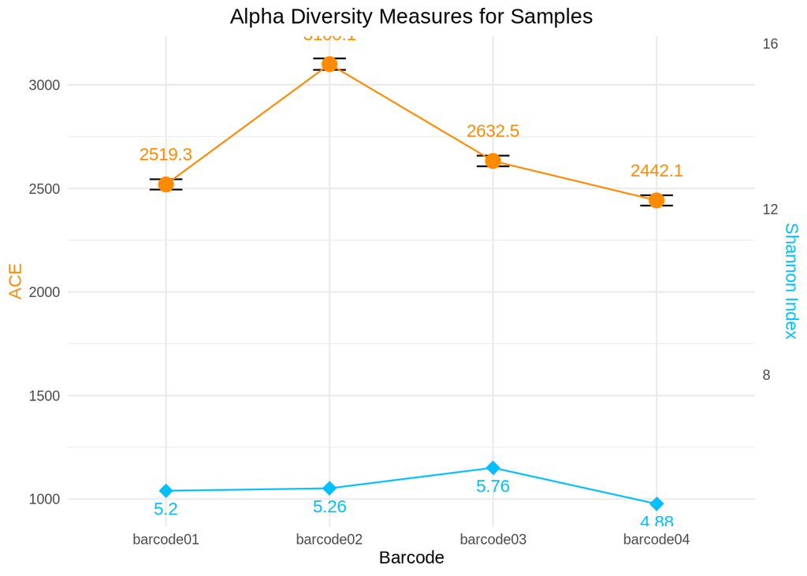

```r
if (!"Barcode" %in% colnames(richness_data)) {
  richness_data$Barcode <- rownames(richness_data)
}

# Create the plot
ggplot(richness_data, aes(x = Barcode)) +
  geom_errorbar(aes(ymin = ACE - se.ACE, ymax = ACE + se.ACE), width = 0.2, color = "black") +
  geom_point(aes(y = ACE), color = "darkorange", size = 4) +  # Changed color for contrast and increased size
  geom_line(aes(y = ACE, group = 1), color = "darkorange") +  # Matched line color with points
  geom_point(aes(y = Shannon * 200), color = "deepskyblue", shape = 18, size = 4) +  # Changed color for contrast and shape
  geom_line(aes(y = Shannon * 200, group = 2), color = "deepskyblue") +  # Matched line color with points
  geom_text(aes(y = ACE, label = round(ACE, 1)), vjust = -2, color = "darkorange") +  # Added data labels for ACE
  geom_text(aes(y = Shannon * 200, label = round(Shannon, 2)), vjust = 2, color = "deepskyblue") +  # Added data labels for Shannon
  theme_minimal() +
  labs(title = "Alpha Diversity Measures for Samples", x = "Barcode", y = "ACE and Shannon Index") +
  scale_y_continuous(
    name = "ACE",
    sec.axis = sec_axis(~ . / 200, name = "Shannon Index")  # Labelled the secondary axis more clearly
  ) +
  theme(
    plot.title = element_text(hjust = 0.5),  # Centered the plot title
    axis.title.y = element_text(color = "darkorange"),  # Colored y-axis title to match ACE points
    axis.title.y.right = element_text(color = "deepskyblue")  # Colored secondary y-axis title to match Shannon points
  )
```